# Example trials

Published

July 29, 2024

Modified

Example trials are provided to give insight into typical cell sample sizes as well as the level of uncertainty associated with the parameter estimation process. Examples are from trials at their maximum sample size with all follow up completed. Sequential variants with adaptations will be added later.

## Null scenario

Table 1 shows a summary of the treatment sucesses based on the $n$ patients associated with each combination of design variables when no treatment effects (non-membership effects still retained) in the simulated data of 2500 patients. Given that this is a summary of a single data set, some variation from the underlying simulation parameters is to be expected.

```r
set.seed(11)

sim_spec <- get_sim_spec()

sim_spec$b['r1'] <- 0
sim_spec$b['r2'] <- 0
sim_spec$b['r1d'] <- 0
sim_spec$b['r2d'] <- 0
sim_spec$b['f'] <- 0

ll <- get_trial_data(N = 2500, sim_spec = sim_spec)

gt_tbl <- tbl_ex_trial(ll$d)
gt_tbl
```

|  | Surgical D<sub>a</sub> reveal | Surgical D<sub>a</sub> assigned | Surgical D<sub>a</sub> received | Duration D<sub>b</sub> reveal | Duration D<sub>b</sub> assigned | Type D<sub>c</sub> reveal | Type D<sub>c</sub> assigned | Response y | Response n | Response MLE (p<sub>y</sub>) | Response TRUE (p<sub>y</sub>)<sup>1</sup> |
| --- | --- | --- | --- | --- | --- | --- | --- | --- | --- | --- | --- |
| early |  |  |  |  |  |  |  |  |  |  |  |
|  | 0 | 0 | 0 | 0 | 0 | 0 | 0 | 188 | 270 | 0.70 | 0.68 |
|  | 0 | 0 | 0 | 0 | 0 | 1 | 0 | 122 | 195 | 0.63 | 0.63 |
|  | 0 | 0 | 0 | 0 | 0 | 1 | 1 | 149 | 228 | 0.65 | 0.63 |
|  | 0 | 0 | 1 | 1 | 0 | 0 | 0 | 9 | 13 | 0.69 | 0.67 |
|  | 0 | 0 | 1 | 1 | 0 | 1 | 0 | 8 | 13 | 0.62 | 0.62 |
|  | 0 | 0 | 1 | 1 | 0 | 1 | 1 | 6 | 10 | 0.60 | 0.62 |
|  | 0 | 0 | 1 | 1 | 1 | 0 | 0 | 12 | 18 | 0.67 | 0.67 |
|  | 0 | 0 | 1 | 1 | 1 | 1 | 0 | 5 | 8 | 0.62 | 0.62 |
|  | 0 | 0 | 1 | 1 | 1 | 1 | 1 | 6 | 10 | 0.60 | 0.62 |
| subtotal | — | — | — | — | — | — | — | 505 | 765 | 0.66 | — |
| late |  |  |  |  |  |  |  |  |  |  |  |
|  | 0 | 0 | 0 | 0 | 0 | 0 | 0 | 1 | 1 | 1.00 | 0.61 |
|  | 0 | 0 | 0 | 0 | 0 | 1 | 0 | 2 | 5 | 0.40 | 0.55 |
|  | 0 | 0 | 0 | 0 | 0 | 1 | 1 | 1 | 1 | 1.00 | 0.55 |
|  | 0 | 0 | 1 | 1 | 0 | 1 | 1 | 1 | 3 | 0.33 | 0.53 |
|  | 0 | 0 | 1 | 1 | 1 | 0 | 0 | 3 | 4 | 0.75 | 0.59 |
|  | 0 | 0 | 1 | 1 | 1 | 1 | 0 | 0 | 1 | 0.00 | 0.53 |
|  | 0 | 0 | 1 | 1 | 1 | 1 | 1 | 0 | 2 | 0.00 | 0.53 |
|  | 0 | 0 | 2 | 1 | 0 | 0 | 0 | 3 | 3 | 1.00 | 0.62 |
|  | 0 | 0 | 2 | 1 | 0 | 1 | 0 | 2 | 2 | 1.00 | 0.56 |
|  | 0 | 0 | 2 | 1 | 0 | 1 | 1 | 0 | 3 | 0.00 | 0.56 |
|  | 0 | 0 | 2 | 1 | 1 | 0 | 0 | 1 | 3 | 0.33 | 0.62 |
|  | 0 | 0 | 2 | 1 | 1 | 1 | 0 | 3 | 4 | 0.75 | 0.56 |
|  | 0 | 0 | 2 | 1 | 1 | 1 | 1 | 1 | 2 | 0.50 | 0.56 |
|  | 1 | 0 | 0 | 0 | 0 | 0 | 0 | 146 | 233 | 0.63 | 0.63 |
|  | 1 | 0 | 0 | 0 | 0 | 1 | 0 | 108 | 192 | 0.56 | 0.57 |
|  | 1 | 0 | 0 | 0 | 0 | 1 | 1 | 99 | 172 | 0.58 | 0.57 |
|  | 1 | 1 | 1 | 1 | 0 | 0 | 0 | 21 | 41 | 0.51 | 0.63 |
|  | 1 | 1 | 1 | 1 | 0 | 1 | 0 | 15 | 28 | 0.54 | 0.57 |
|  | 1 | 1 | 1 | 1 | 0 | 1 | 1 | 26 | 45 | 0.58 | 0.57 |
|  | 1 | 1 | 1 | 1 | 1 | 0 | 0 | 26 | 44 | 0.59 | 0.63 |
|  | 1 | 1 | 1 | 1 | 1 | 1 | 0 | 19 | 30 | 0.63 | 0.57 |
|  | 1 | 1 | 1 | 1 | 1 | 1 | 1 | 15 | 25 | 0.60 | 0.57 |
|  | 1 | 1 | 2 | 1 | 0 | 0 | 0 | 48 | 79 | 0.61 | 0.63 |
|  | 1 | 1 | 2 | 1 | 0 | 1 | 0 | 34 | 62 | 0.55 | 0.57 |
|  | 1 | 1 | 2 | 1 | 0 | 1 | 1 | 33 | 56 | 0.59 | 0.57 |
|  | 1 | 1 | 2 | 1 | 1 | 0 | 0 | 54 | 78 | 0.69 | 0.63 |
|  | 1 | 1 | 2 | 1 | 1 | 1 | 0 | 35 | 61 | 0.57 | 0.57 |
|  | 1 | 1 | 2 | 1 | 1 | 1 | 1 | 28 | 54 | 0.52 | 0.57 |
| subtotal | — | — | — | — | — | — | — | 725 | 1234 | 0.59 | — |
| chronic |  |  |  |  |  |  |  |  |  |  |  |
|  | 0 | 0 | 0 | 0 | 0 | 0 | 0 | 23 | 38 | 0.61 | 0.66 |
|  | 0 | 0 | 0 | 0 | 0 | 1 | 0 | 23 | 30 | 0.77 | 0.61 |
|  | 0 | 0 | 0 | 0 | 0 | 1 | 1 | 21 | 33 | 0.64 | 0.61 |
|  | 0 | 0 | 1 | 1 | 0 | 0 | 0 | 10 | 17 | 0.59 | 0.65 |
|  | 0 | 0 | 1 | 1 | 0 | 1 | 0 | 12 | 19 | 0.63 | 0.59 |
|  | 0 | 0 | 1 | 1 | 0 | 1 | 1 | 12 | 17 | 0.71 | 0.59 |
|  | 0 | 0 | 1 | 1 | 1 | 0 | 0 | 12 | 20 | 0.60 | 0.65 |
|  | 0 | 0 | 1 | 1 | 1 | 1 | 0 | 8 | 17 | 0.47 | 0.59 |
|  | 0 | 0 | 1 | 1 | 1 | 1 | 1 | 5 | 12 | 0.42 | 0.59 |
|  | 0 | 0 | 2 | 1 | 0 | 0 | 0 | 46 | 60 | 0.77 | 0.68 |
|  | 0 | 0 | 2 | 1 | 0 | 1 | 0 | 27 | 47 | 0.57 | 0.62 |
|  | 0 | 0 | 2 | 1 | 0 | 1 | 1 | 23 | 33 | 0.70 | 0.62 |
|  | 0 | 0 | 2 | 1 | 1 | 0 | 0 | 41 | 56 | 0.73 | 0.68 |
|  | 0 | 0 | 2 | 1 | 1 | 1 | 0 | 31 | 44 | 0.70 | 0.62 |
|  | 0 | 0 | 2 | 1 | 1 | 1 | 1 | 30 | 58 | 0.52 | 0.62 |
| subtotal | — | — | — | — | — | — | — | 324 | 501 | 0.65 | — |
| total | — | — | — | — | — | — | — | 1554 | 2500 | 0.62 | — |

<sup>1</sup> Transformed from the log-odds of response as used in the linear predictor to simulate data.

Table 1: Summary of simulated trial data when no treatment effects present

Model the simulated data first using standard normal priors on the domain level treatment effects, then increasing the prior standard deviation to ten in order to see if there is any movement in the posterior summary.

```r
lsd <- get_stan_data(ll$d)
ld <- lsd$ld
d_s <- copy(lsd$d_s)

m2 <- cmdstanr::cmdstan_model("stan/model-sim-04.stan")

f_null_1 <- m2$sample(
  ld, iter_warmup = 1000, iter_sampling = 10000,
  parallel_chains = 2, chains = 2, refresh = 0, show_exceptions = F,
  max_treedepth = 13)
```

```
Running MCMC with 2 parallel chains...

Chain 1 finished in 4.5 seconds.
Chain 2 finished in 5.1 seconds.

Both chains finished successfully.
Mean chain execution time: 4.8 seconds.
Total execution time: 5.2 seconds.
```

```r
post_1 <- data.table(f_null_1$draws(variables = c(c("a0", "m", "b")), format = "matrix"))
post_1 <- melt(post_1, measure.vars = names(post_1))
d_tbl_1 <- post_1[, .(
  prior = "normal(0, 1)",
  mu = mean(value),
  q_025 = quantile(value, prob = 0.025),
  q_975 = quantile(value, prob = 0.975)
), keyby = variable]
d_tbl_1[, name_tru := names(unlist(sim_spec))]
d_tbl_1[, tru := unlist(sim_spec)]

# compare when prior sd is set to 10 for trt effects

ld$pri_m_sd <- rep(10, length(ld$pri_m_sd))
ld$pri_b_sd <- rep(10, length(ld$pri_b_sd))

f_null_2 <- m2$sample(
  ld, iter_warmup = 1000, iter_sampling = 10000,
  parallel_chains = 2, chains = 2, refresh = 0, show_exceptions = F,
  max_treedepth = 13)
```

```
Running MCMC with 2 parallel chains...

Chain 2 finished in 5.0 seconds.
Chain 1 finished in 5.6 seconds.

Both chains finished successfully.
Mean chain execution time: 5.3 seconds.
Total execution time: 5.7 seconds.
```

```r
post_2 <- data.table(f_null_2$draws(variables = c(c("a0", "m", "b")), format = "matrix"))
post_2 <- melt(post_2, measure.vars = names(post_2))
d_tbl_2 <- post_2[, .(
  prior = "normal(0, 10)",
  mu = mean(value),
  q_025 = quantile(value, prob = 0.025),
  q_975 = quantile(value, prob = 0.975)
), keyby = variable]
d_tbl_2[, name_tru := names(unlist(sim_spec))]
d_tbl_2[, tru := unlist(sim_spec)]
```

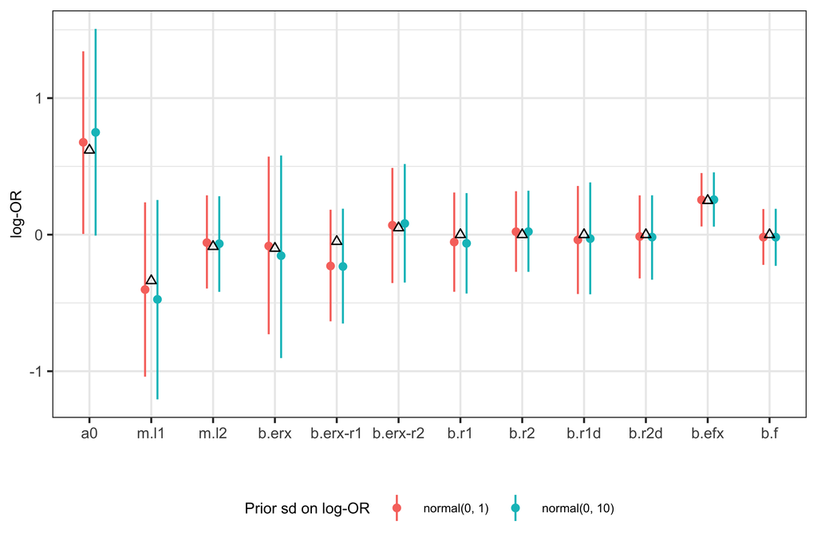

```r
d_fig <- rbind(
  d_tbl_1, d_tbl_2
)
d_fig$name_tru <- factor(d_fig$name_tru, levels = unique(d_fig$name_tru))

# https://www.andrewheiss.com/blog/2022/12/08/log10-natural-log-scales-ggplot/

ggplot(d_fig, aes(x = name_tru, y = mu, col = prior)) +
  scale_x_discrete("") +
  scale_y_continuous("log-OR") +
  scale_color_discrete("Prior sd on log-OR") +
  geom_point(data = d_fig, aes(x = name_tru, y = mu), position = position_dodge(width = 0.4)) +
  geom_linerange(aes(ymin = q_025, ymax = q_975), position = position_dodge2(width = 0.4)) +
  geom_point(data = d_fig, aes(x = name_tru, y = tru), col = 1, pch = 2)
```